# ESM 232 - Assignment 2

Bridget Gibbons, Kaili Brande

4/10/2020

### Loading in the climate data provided (clim.txt):

```r
# load tidyverse
# read in the climate data

library(tidyverse)
clim = data.frame(read_csv("clim.csv"))
```

## 3.

### Bringing in our model from our .R file:

### Using our model to estimate almond yield anomalies for each year in the record:

```r
source("yield_function_final.R")

yield_function_final(climate = clim)
```

```
## [[1]]
##    year         YA
## 1  1989 -0.1993106
## 2  1990 -0.3089846
## 3  1991 -0.5962362
## 4  1992 -0.6865190
## 5  1993 -0.5833374
## 6  1994 -0.3635580
## 7  1995 -0.1172668
## 8  1996 -0.6511231
## 9  1997 -0.6087975
## 10 1998 -0.6656323
## 11 1999 -0.1436364
## 12 2000 -0.6294976
## 13 2001 -0.4834664
```

[output cut: 17 more lines]

The yearly yield anomaly values are listed above. In addition, the minimum value (or maximum amount of anomaly from the mean) is -0.687 ton/acre in year 1992; and the maximum value (or minimum amount of anomaly from the mean) is -0.117 ton/acre in year 1995.

### Graphing the results:

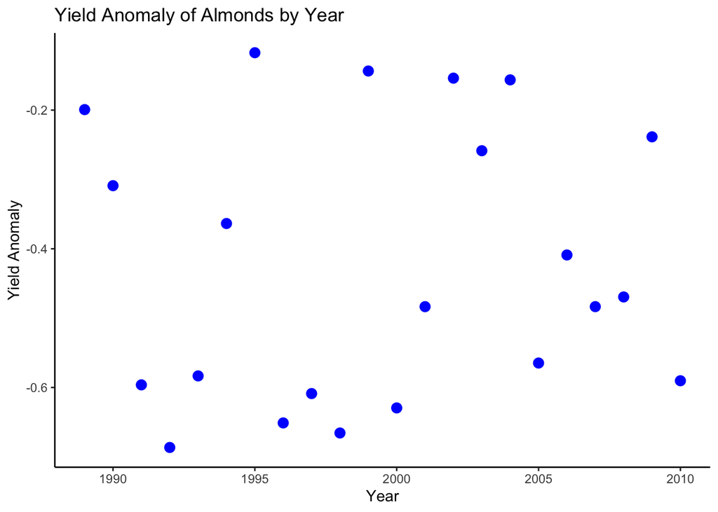

```r
# Convert the yield_anomaly_year portion of our results into a data frame:

results <- yield_function_final(climate = clim)

results_df <- as.data.frame(results[1])

# calculate mean

mean_result <- mean(results_df$YA)

# graph the data:

library(ggplot2)

ggplot(results_df, aes(x = year, y = YA)) + geom_point(color = "blue", size = 3) + theme_classic() + labs(x = "Year", y = "Yield Anomaly", title = "Yield Anomaly of Almonds by Year")
```

## 4.

### Estimating the mean annual yield anomaly if the last 20 years had been 2C warmer:

```r
# create new data frame for warmer climates by adding 2 to each tmin_c value

clim_warmer <- clim %>%
  mutate(tmin_c = tmin_c + 2)

results_2c <- yield_function_final(climate = clim_warmer)

results_2c_df <- as.data.frame(results_2c[1])

# take the mean of the new values

mean_yield_anomaly_2c <- mean(results_2c_df$YA)
mean_yield_anomaly_2c
```

```
## [1] -0.6556624
```

The mean annual yield anomaly if the last 20 years had been 2C warmer is -0.656 ton/acre.

## 5.

### Varying one of the parameters by sampling from a normal distribution; with mean the value from Lobell et al., (2006) and standard deviation 10% of the mean:

```r
# create parameter values for x4 from a normal distribution
# it needs to have 22 values

new_param_x4 <- as.data.frame(matrix(nrow = 22, ncol = 1)) # create a data frame to store the parameter values
colnames(new_param_x4) = c("x4_new")

new_param_x4$x4_new <- rnorm(n = 22, mean = 0.0043, sd = 0.00043) # fill in the dataframe column with new parameter values for x4: centered on a mean of 0.0043 with a standard deviation of 10% of the mean
```

### Creating a box plot of mean annual yield anomaly for baseline and 2C climate (boxes show variation due to uncertainty in the parameter):

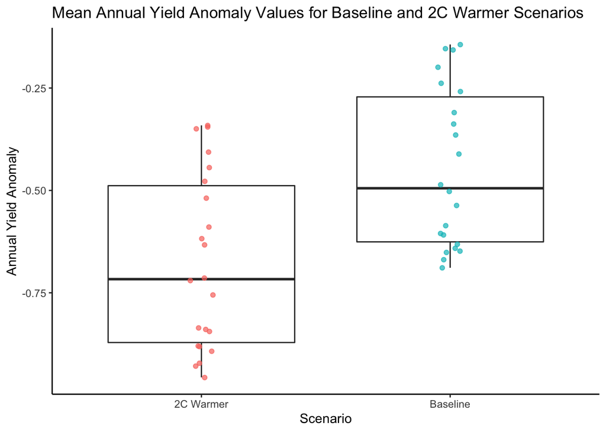

```r
# run the model for baseline temperature using new x4 parameter

baseline_newparam <- yield_function_final(climate = clim, x4 = new_param_x4$x4_new)

# run the model for 2C warmer temperature using new x4 parameter

warmer_newparam <- yield_function_final(climate = clim_warmer, x4 = new_param_x4$x4_new)

# get the relevant values out of the list and into dataframe to use in the plot
# prepare the data in tidy format in single dataframe for boxplot

baseline_newparam_df <- as.data.frame(baseline_newparam[1]) %>%
  mutate(type = "Baseline")

warmer_newparam_df <- as.data.frame(warmer_newparam[1]) %>%
  mutate(type = "2C Warmer")

# calculate mean values

mean_anom_base <- mean(baseline_newparam_df$YA)
mean_anom_2c <- mean(warmer_newparam_df$YA)

boxplot_df <- rbind(baseline_newparam_df, warmer_newparam_df)

# create a box plot to compare the two

#boxplot_param_df$year <- as.factor(boxplot_param_df$year)

boxplot_yields <- ggplot(boxplot_df, aes(x = type, y = YA)) +
  geom_boxplot() +
  geom_jitter(aes(color = type), width = 0.05, alpha = 0.7) +
  theme_classic() +
  labs(x = "Scenario", y = "Annual Yield Anomaly", title = "Mean Annual Yield Anomaly Values for Baseline and 2C Warmer Scenarios") +
  theme(legend.position = "none")

boxplot_yields
```

```r
mean_anom_base
```

```
## [1] -0.4469979
```

```r
mean_anom_2c
```

```
## [1] -0.6771242
```